# Nick van der Zandt

Lead Assessor / Power BI Developer

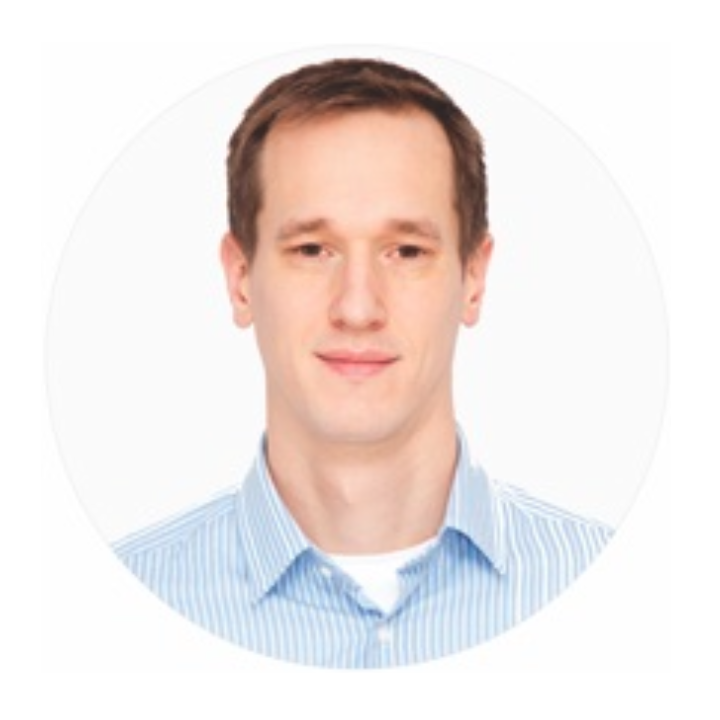

Nick van der Zandt

Lead Assessor / Power BI Developer

# 1 Profiel

## 1.1 Over mij

Ik ben een autonome doorzetter met een sterke visie. Ik houd van creëren, presteren en tot in detail optimaliseren. Eerlijkheid, respect en humor vind ik belangrijk in mensen, kwaliteit en originaliteit in werk. Ik vind geluk in het maximale halen uit mezelf en anderen. Mijn dag is geslaagd als ik een verschil heb gemaakt.

Nu ik mijn post-hbo-opleiding Big Data Scientist succesvol heb afgerond, zoek ik een uitdagende rol waarin ik mijn passie voor data kan inzetten voor een betekenisvolle impact. Liefst op maatschappelijk vlak. Met een stevige basis in data-analyse en visualisatie, en een groeiende interesse in data engineering, ben ik klaar voor de volgende stap in mijn carrière.

Veghel, Noord-Brabant

0641873330

nickvdz@me.com

Bekijk mijn [portfolio](https://nzprj.github.io/portfolio/)

## 1.2 Competenties

| HTML/CSS | ●●●●●●●●●● |  |
| --- | --- | --- |

| MS Excel | ●●●●●●●●●● |  |
| --- | --- | --- |

| MS Power BI | ●●●●●●●●●● |  |
| --- | --- | --- |

| Python | ●●●●●●●●●● |  |
| --- | --- | --- |

| R | ●●●●●●●●●● |  |
| --- | --- | --- |

| SQL | ●●●●●●●●●● |  |
| --- | --- | --- |

## Talen

| Engels (schrijven) | ●●●●●●●●●● |  |
| --- | --- | --- |

| Engels (spreken) | ●●●●●●●●●● |  |
| --- | --- | --- |

| Nederlands (schrijven) | ●●●●●●●●●● |  |
| --- | --- | --- |

| Nederlands (spreken) | ●●●●●●●●●● |  |
| --- | --- | --- |

## 1.3 Kwaliteiten en valkuilen

Mijn kracht ligt in het combineren van mijn analytisch denkvermogen en mijn sterke inlevingsvermogen. Ik voel snel aan wat zowel stakeholders als eindgebruikers nodig hebben en kan daardoor vraagstukken vanuit verschillende perspectieven benaderen. Dit stelt me in staat om complexe gegevens te vertalen naar doordachte data-oplossingen die helder, bruikbaar en relevant zijn voor de doelgroep. Daarbij denk ik na over wat nú werkt, maar ook over wat op de lange termijn duurzaam waarde oplevert.

Ik werk graag gestructureerd en hecht veel waarde aan kwaliteit. Met mijn academisch denkniveau en de vastberadenheid van een topsporter neem ik graag verantwoordelijkheid voor inhoudelijk uitdagende vraagstukken. Ik stel hoge eisen aan mijn werk, omdat ik geloof dat zorgvuldigheid vaak het verschil maakt.

Constante onderbrekingen of ad-hoc beslissingen passen minder goed bij mij. Ik kom het best tot mijn recht in een omgeving waar ruimte is voor diepgang en waar ik écht iets kan opbouwen. Als ik de kans krijg om me ergens in vast te bijten, kom ik in een productieve flow terecht en ben ik op mijn best.

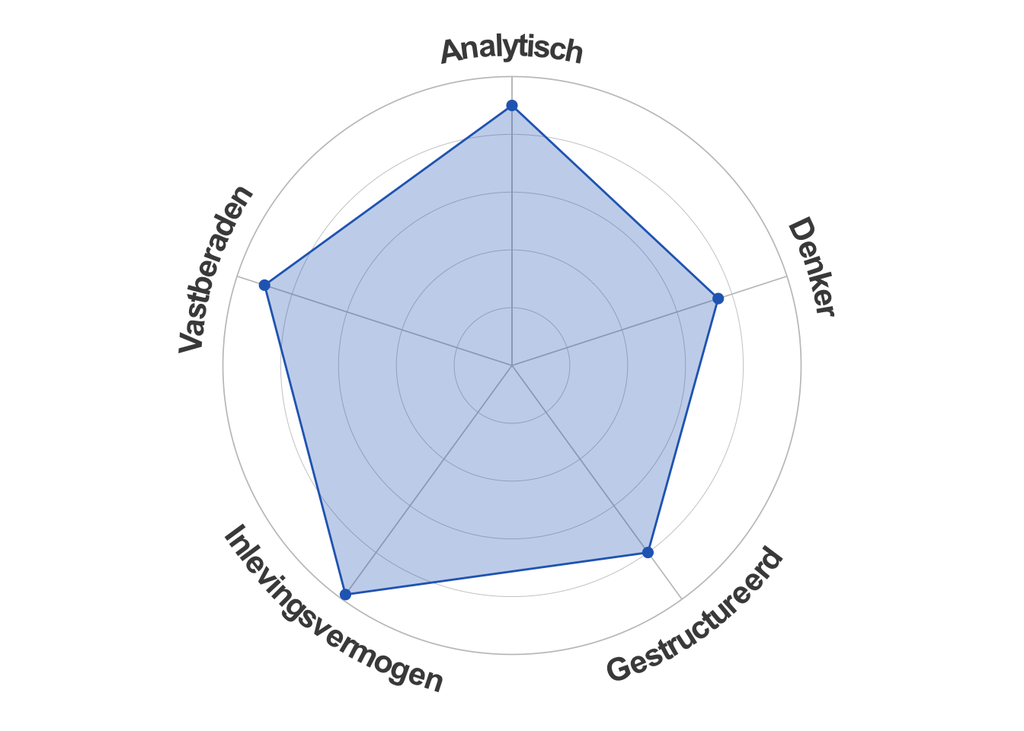

## 1.4 Passies

Data & Coderen

Design

Fotografie

Hiken

Zwemmen

# 2 Opleiding

> Hi Nick! Ik denk dat ik al uitgesproken heb dat ik diep onder de indruk ben van je werk, maar voor de zekerheid wil ik het ook nog op papier zetten: Het rapport dat je hebt gebouwd is niet alleen goed als opdracht, het is ook zeer goed als je het tegen een professionele maatstaf houdt. Je geeft een uitgebreid inzicht in de data en je bewaart de rust in je notebook. Daarnaast heb je de juiste reproduceerbare implementatie gekozen. Verder is niet alleen je rapport goed en overzichtelijk, ook het notebook daarachter is zorgvuldig en overzichtelijk gemaakt.

> Ido de Baat Docent Big Data Scientist, Inholland Feedback n.a.v. opdracht module 2: Big Data Analtics

Udemy, Online

2025 - Heden

Azure Data Factory: Data Engineering on Azure and Fabric

Resultaat

Ingeschreven

Cursusinhoud

- **Azure-opslagoplossingen**: Werken met Azure Blob Storage en Azure Data Lake Gen2.
- **Azure Data Factory**: Ontdekken van basiscomponenten zoals Linked Services, Datasets, Data Flows, Pipelines en Integratie Runtimes.
- **Gegevensintegratie**: Integreren van gegevens uit verschillende formaten zoals CSV, JSON en Parquet.
- **Gegevensstromen en transformaties**: Werken met Data Flows, Control Flow en transformaties in Azure Data Factory.
- **Automatisering**: Maken van schema’s, triggers en werken met parameters en variabelen om workflows te automatiseren.
- **Power BI en Azure SQL**: Vullen van een datawarehouse en data beschikbaar maken via Power BI en SQL-databases.

[output not shown]

|  | ROC Midden Nederland, Veghel |  |
| --- | --- | --- |
|  | Bedrijfsopleiding |  |
| 2013 - 2016 | Operator VAPRO B |  |
|  | Resultaat | Diploma: Branchediploma VAPRO B |

|  | Universiteit van Tilburg (UvT), Tilburg |  |
| --- | --- | --- |
|  | Wetenschappelijk onderwijs (WO) |  |
| 2002 - 2007 | Bachelor of Science Psychologie |  |
|  | Resultaat | Diploma: Bachelor of Science (BSc.) |
|  | Major | Klinische kinder- en jeugdpsychologie |
|  | Minor | Cognitieve Neurowetenschappen |

|  | Gymnasium Bernrode, Heeswijk - Dinther |  |
| --- | --- | --- |
|  | Voorbereidend Wetenschappelijk Onderwijs (VWO) |  |
| 1995 - 2001 | VWO Gymnasium |  |
|  | Resultaat | Diploma: Voorbereidend Wetenschappelijk Onderwijs (VWO) |
|  | Examenvakken | Nederlands, Latijn, Engels, Wiskunde A, Wiskunde B, Economie I, Economie II, Geschiedenis |

# 3 Ervaring

Royal Friesland Campina, Veghel

Farmaceutische industrie, Voedingsindustrie, Zuivelindustrie

2018 - Heden

Lead Assessor / PowerBI Developer

Continuous Improvement (Learning & Development)

- Ontwikkelen, beheren en optimaliseren van L&D Dashboards en rapportages in Power BI
- Ontwikkelen, inrichten en beheren van L&D data en optimaliseren van de workflow
- Adviseren en rapporteren aan teammanagers over de voortgang van opleiden
- Ontwikkelen, inrichten en beheren van werkplekopleidingen op projectbasis
- Begeleiden, afnemen en beoordelen van werkplekassessments bij operators
- Trainen en coachen praktijkbegeleiders, -trainers en operators

2012 - 2018

Procesoperator

Productie

- Beheersen en optimaliseren van technische processen
- Analyseren van procesdata na storingen en andere afwijkingen in het proces
- Vastleggen en overdragen van procesinformatie
- Begeleiden en opleiden van personeel

Diversus, Sint-oedenrode

ICT

2006 - 2012

Zelfstandig ondernemer

Webdesign en -advies

- Ontwerpen van commerciële websites met focus op usability
- Testen en verbeteren van websites en concepten met focus op usability
- Trainingen ontwikkelen en geven aan eindgebruikers van websites en software
- Schrijven van protocollen, handleidingen, oﬀertes, functionele ontwerpen en andere documentatie
- Beheren van de volledige zakelijke administratie

Koninklijke Nederlandse Zwembond (KNZB), Eindhoven

Wedstrijdzwemmen

1999 - 2002

Professioneel atleet wedstrijdzwemmen

- Deelname aan internationale wedstrijden op europees en wereldniveau
- Deelname aan trainingsstages van het Nationale team door heel Europa

# 4 Portfolio

## 4.1 L&D Dashboard

**Dynamisch en volledig geïntegreerd Power BI-dashboard.** In dit dashboard breng ik een grote hoeveelheid HR- en L&D-data samen in een relationeel datamodel, waarbij ik privacygevoelige informatie bescherm met Row Level Security (RLS). Dit dashboard biedt managers uit alle disciplines in de organisatie inzicht in L&D gerelateerde KPI’s en stelt hen in staat om gericht te sturen op verplichte trainingen en werkplekopleidingen.

Ik ben verantwoordelijk voor zowel de technische ontwikkeling als de visuele presentatie en werk nauw samen met stakeholders in alle lagen van de organisatie. Mijn kracht ligt in het vertalen van hun behoeften naar heldere, doelgerichte visuals die een directe en meetbare impact hebben op hun besluitvorming.

[Bekijk het L&D Dashboard](https://nzprj.github.io/portfolio/ld_dashboard.html)

## 4.2 Rapport zwemmarathon

**Data rapport 24-uurs zwemmarathon.** Voor dit rapport heb ik een dataset geanalyseerd van de 24-uurs zwemmarathon, waaraan ik zelf heb deelgenomen. De opdracht bestond uit het inladen, transformeren, opschonen en analyseren van de gegevens in een RMarkdown notebook en deze te presenteren in een overzichtelijk en leesbaar rapport.

Ik heb hierbij gebruik gemaakt van diverse technieken met het R pakket ggplot2 als basis. Daarnaast heb ik (S)CSS en HTML toegepast om het ontwerp van het rapport verder te verfijnen. Dit project is door de docent beoordeeld met de maximale score.

NB. Ik heb met dezelfde dataset ook een **dynamisch Power BI dashboard** ontwikkeld, waarin niet alleen mijn eigen resultaten zichtbaar zijn, maar ook die van mijn teamgenoten, waarbij je via slicers ook prestaties van zwemmers onderling met elkaar kan vergelijken.

[Bekijk het data rapport zwemmarathon](https://nzprj.github.io/portfolio/24u.html)

## 4.3 Mijn CV

**Data-gedreven CV als webpagina.** Voor mijn CV heb ik R, CSS en HTML gebruikt om een visueel aantrekkelijke webpagina te creëren met een floating TOC. De inhoud haal ik op uit Google Sheets en verwerk ik in RStudio. Van daaruit genereer ik een nette en gestructureerde HTML-pagina.

Bij het ontwerpen heb ik mijn passie voor data en design gecombineerd om mijn vaardigheden en ervaring op een heldere en esthetische manier te presenteren. Ik geloof dat goed gestructureerde data krachtiger spreekt dan loze woorden, en met dit CV laat ik zien wat ik kan.

## 4.4 Toegepaste data wetenschap

Voor de laatste module van mijn opleiding heb ik in R een script ontwikkeld dat semi-gestructureerde data van het internet ophaalt via webscraping. Het script slaat de ruwe data op in een raw layer en schoont het vervolgens op. De opgeschoonde data wordt vervolgens naar verschillende SQLite-databases weggeschreven.

Op basis van de opgeschoonde data, past het script de namen van de ruwe datafiles aan volgens een vaste naming convention. Daarnaast heb ik een notificatiesysteem geïmplementeerd, zodat ik via e-mail op de hoogte blijf van nieuwe resultaten en eventuele foutmeldingen in het script, zoals wanneer de website een update krijgt en de structuur verandert.

Ook dit project is door de docent beoordeeld met de maximale score. Omdat het om een script gaat zonder visueel resultaat, kan ik alleen de feedback van de docent tonen. Deze staat onder de referenties.

# 5 Referenties

## 5.1 Ido de Baat

**Docent Big Data Scientist, Inholland.**  
Op verzoek zijn de contactgegevens van Ido beschikbaar.

> Dit is geen studie opdracht meer, dit is een hele repo! Ik heb ook echt even de tijd moeten nemen om het goed door te nemen, maar het ziet er goed uit! De enorme toewijding die je in je project hebt gestopt is duidelijk zichtbaar en de diepgang die je in je onderzoek hebt gestopt is indrukwekkend. Ik kan heel duidelijk zien dat je je in ieder onderwerp vast bijt en aan ieder draadje trekt om te kijken wat er achter zit. Ook is het duidelijk dat je nieuwsgierig bent naar de verschillende implementaties en door zoekt totdat je een elegante oplossing gevonden hebt en niet de eerste de beste werkende oplossing kopieert van ChatGPT.

> Ik hoop oprecht dat je een baan kan vinden waarin je de ruimte krijgt om dit door te ontwikkelen. Succes en veel plezier!

> Ido de Baat Docent Big Data Scientist, Inholland Feedback n.a.v. opdracht module 3: Applied Data Science